# A Timestamp Audit of Filing-Tone Signals

A known-truth worked final-project example

FIN 7057

2026-09-27

## The research question

Company filings carry **tone**. The hopeful pitch: a contextual reader extracts more useful information than a word list.

The disciplined question is narrower:

> Does a richer filing-tone reader predict the drift **after the filing is public**, better than a simple lexicon, **once we respect the timestamp and pay costs**?

*Everything hinges on those last two conditions.*

## Prior evidence narrows the question

- Finance-specific dictionaries improve on generic word lists (Loughran and McDonald 2011).
- Finance-adapted contextual models improve several sentiment-classification tasks (Araci 2019; Huang, Wang, and Yang 2023).
- Filing-language changes have been associated with later firm outcomes and returns (Cohen, Malloy, and Nguyen 2020).

**Unresolved here:** does a richer text score improve a feasible downstream return-ranking decision relative to the simple finance baseline?

## The data (and the planted truth)

Reproducible **synthetic filings** (a stand-in for SEC EDGAR — runs offline, fixed seed). Each filing has a latent tone, and two returns follow it:

- an **announcement** jump at the filing date — strongly tone-driven, and *untradeable* before the filing is public;
- a faint **post-filing drift** over the next 20 days — weakly tone-driven, and the only genuinely tradeable target.

The filing is dated **45 days after** the period it describes. That gap is the central information-clock risk.

## Two readers of the text

- **Baseline** — a shallow Loughran–McDonald-style lexicon: net (positive − negative) hits. Cheap, transparent, hard to beat.
- **Candidate** — a richer contextual-reader proxy. The pipeline can call **FinBERT**, but the committed offline output uses a deterministic stand-in.

The candidate must improve on the baseline out of sample before its additional complexity counts for anything.

## The leakage trap

Align tone to the **period-end** date and the return window swallows the announcement pop — a move you could never have traded. Align to the **filing date** and you keep only the honest, post-public drift.

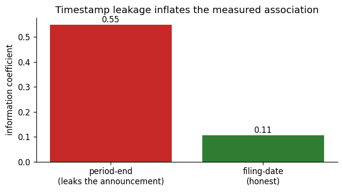

The same score and text produce roughly **five times the measured association** under the inadmissible timestamp.

## Honest, time-aware evaluation

Evaluate out of sample (never shuffle time). Compare the **information coefficient** and a top-minus-bottom **tercile spread**, net of a 10 bp cost.

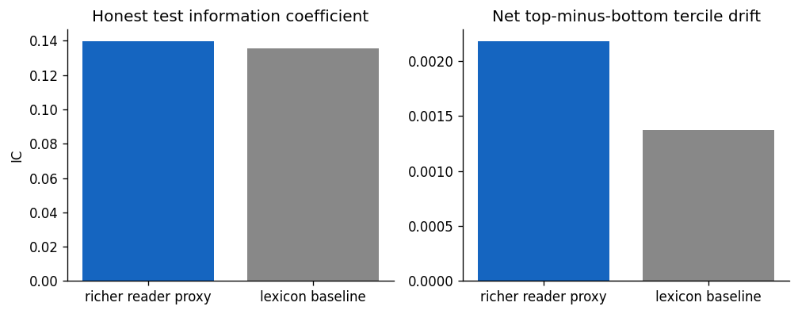

## The result

- Removing the timestamp leak cuts the apparent signal by **~5×**.
- On the honest target, the richer reader’s edge is **small and does not clearly beat the lexicon**.
- The experiment does not provide enough uncertainty evidence to treat that small difference as stable.

**This is a good negative result** — the disciplined finding is that the easy “NLP alpha” was mostly leakage.

## Limitations

- **Synthetic data** — the experiment does not estimate predictability in real SEC filings.
- **Offline proxy** — the committed run does not test FinBERT itself.
- **One universe, one horizon** — no sector/size controls, a single tercile cut.
- **Stylized 10 bp cost** — a filing-clustered strategy would likely pay more impact.
- **No multiple-testing accounting** — a real model/lexicon/horizon search needs a deflated Sharpe and a trial count.

## Takeaway

The question was never *“does the model sound fluent?”*

It is *“does its tone predict a return you could actually have traded, after costs?”*

Here — **barely.** And that answer, honestly arrived at, is the assignment.

## References

Araci, Doğu. 2019. “FinBERT: Financial Sentiment Analysis with Pre-Trained Language Models.” *arXiv Preprint arXiv:1908.10063*. https://doi.org/10.48550/arXiv.1908.10063.

Cohen, Lauren, Christopher Malloy, and Quoc Nguyen. 2020. “Lazy Prices.” *The Journal of Finance* 75 (3): 1371–1415. https://doi.org/10.1111/jofi.12885.

Huang, Allen H., Hui Wang, and Yi Yang. 2023. “FinBERT: A Large Language Model for Extracting Information from Financial Text.” *Contemporary Accounting Research* 40 (2): 806–41. https://doi.org/10.1111/1911-3846.12832.

Loughran, Tim, and Bill McDonald. 2011. “When Is a Liability Not a Liability? Textual Analysis, Dictionaries, and 10-Ks.” *The Journal of Finance* 66 (1): 35–65. https://doi.org/10.1111/j.1540-6261.2010.01625.x.